# Tutorial 04 — Immune Response

## 5 Bistable immune clearance threshold

A hallmark of innate immunity is **bistability**: the same immune parameters can either clear bacteria entirely or fail, depending on the initial bacterial load. This arises from competition between bacterial growth and immune killing.

**Mechanistic analysis (Hill module, logistic growth):**

```
dB/dt = μ · (1 − B/K) · B  −  imm_max · B / (imm_kill50 + B)
```

Per-capita net growth `f(B) = μ·(1−B/K) − imm_max/(imm_kill50 + B)` has:

- `f(0) = μ − imm_max/imm_kill50` — **negative** when `imm_max > μ · imm_kill50` (immune kills faster than bacteria grow at very low density)
- `f` rises as B increases (killing saturates), crosses zero at an **unstable threshold** B*
- Returns negative near K (logistic suppression dominates)

This creates two stable states: **B = 0** (immune clearance) and **B ≈ K** (bacterial persistence), separated by the unstable threshold B*.

**Parameters chosen so that B* ≈ 10⁷ CFU/mL:**

| Parameter | Value | Role |
| --- | --- | --- |
| `imm_max` | 2×10⁷ | `imm_max / imm_kill50 = 2 > μ = 1` → clearance at low B |
| `imm_kill50` | 10⁷ | Sets the threshold density |
| `μ` | 1.0 h⁻¹ | Growth rate |
| `K` | 10⁹ | Logistic ceiling |

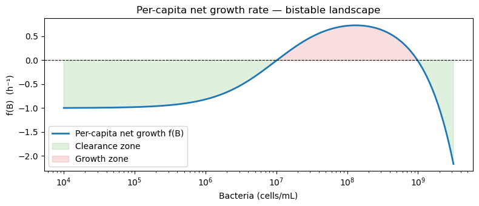

```
  Unstable threshold B* ≈ 9.96e+06 cells/mL
  Unstable threshold B* ≈ 9.66e+08 cells/mL
```

```python
# Verify the bistable conditions analytically
mu        = 1.0
K_cap     = 1e9
imm_max   = 2e7
imm_kill50 = 1e7

B_test = np.logspace(4, 9.5, 300)
f_B    = mu * (1 - B_test / K_cap) - imm_max / (imm_kill50 + B_test)

fig, ax = plt.subplots(figsize=(8, 3.5))
ax.semilogx(B_test, f_B, "C0-", lw=2, label="Per-capita net growth f(B)")
ax.axhline(0, color="k", lw=0.8, ls="--")
ax.fill_between(B_test, f_B, 0,
                where=(f_B < 0), alpha=0.15, color="C2", label="Clearance zone")
ax.fill_between(B_test, f_B, 0,
                where=(f_B > 0), alpha=0.15, color="C3", label="Growth zone")
ax.set(xlabel="Bacteria (cells/mL)", ylabel="f(B)  (h⁻¹)",
       title="Per-capita net growth rate — bistable landscape")
ax.legend()
plt.tight_layout()
plt.show()

# Locate the unstable threshold B*
sign_changes = np.where(np.diff(np.sign(f_B)))[0]
for idx in sign_changes:
    b_star = B_test[idx]
    print(f"  Unstable threshold B* ≈ {b_star:.2e} cells/mL")
```

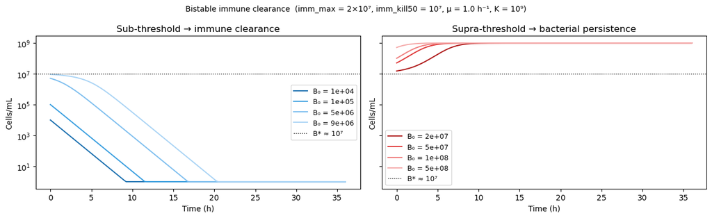

```python
# Demonstrate bistability: sub-threshold vs supra-threshold initial densities
cfg_bi = (
    BASE.with_immunity(
        immune_module = "hill",
        imm_max       = imm_max,
        imm_kill50    = imm_kill50,
    ).build()
)

sub_threshold   = [1e4, 1e5, 5e6, 9e6]    # below B* → immune clearance
supra_threshold = [1.5e7, 5e7, 1e8, 5e8]  # above B* → bacterial persistence

fig, axes = plt.subplots(1, 2, figsize=(13, 4), sharey=True)

for B0, color in zip(sub_threshold,   ["#1a6faf","#3a9fe0","#7fbfef","#aad4f5"]):
    res = solve_ode(PBIModel(cfg_bi, initial_B=np.array([B0]),
                             initial_P=np.zeros(0)), t_end=T_END, dt=0.25)
    axes[0].semilogy(res.time, np.maximum(res.get("B0"), 1),
                     color=color, label=f"B₀ = {B0:.0e}")

for B0, color in zip(supra_threshold, ["#af1a1a","#e03a3a","#ef7f7f","#f5aaaa"]):
    res = solve_ode(PBIModel(cfg_bi, initial_B=np.array([B0]),
                             initial_P=np.zeros(0)), t_end=T_END, dt=0.25)
    axes[1].semilogy(res.time, np.maximum(res.get("B0"), 1),
                     color=color, label=f"B₀ = {B0:.0e}")

for ax, title in zip(axes, ["Sub-threshold → immune clearance",
                              "Supra-threshold → bacterial persistence"]):
    ax.axhline(1e7, ls=":", color="k", lw=1, label="B* ≈ 10⁷")
    ax.set(xlabel="Time (h)", ylabel="Cells/mL", title=title)
    ax.legend(fontsize=9)

plt.suptitle("Bistable immune clearance  "
             "(imm_max = 2×10⁷, imm_kill50 = 10⁷, μ = 1.0 h⁻¹, K = 10⁹)",
             fontsize=10)
plt.tight_layout()
plt.show()
```

## 6 `'custom'` module

Provide a callable with the signature:

```
def my_immune(S, B, I, Imm, config):
    dImmdt  = ...          # float — right-hand side of the Imm ODE
    kill_B  = ...          # ndarray[n] — per-cell killing for active bacteria
    kill_I  = ...          # ndarray[L, n, m] — per-cell killing for infected bacteria
    return (dImmdt, kill_B, kill_I)
```

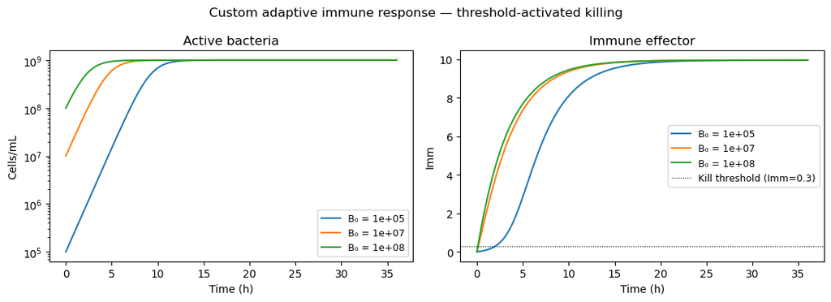

```python
def adaptive_immune(S, B, I, Imm, config):
    B_tot   = float(np.sum(B)) + 1e-30
    # Imm grows proportional to bacterial load, decays otherwise
    dImmdt  = 3.0 * B_tot / (5e6 + B_tot) - 0.3 * Imm
    # Killing activates once Imm crosses 0.3
    k_eff   = 5e-7 * max(0.0, Imm - 0.3)
    kill_B  = k_eff * B
    kill_I  = k_eff * I
    return (dImmdt, kill_B, kill_I)

cfg_custom = (
    BASE.with_immunity(immune_module="custom",
                       immune_function=adaptive_immune)
    .build()
)

fig, axes = plt.subplots(1, 2, figsize=(11, 4))
for B0, color in [(1e5,"C0"),(1e7,"C1"),(1e8,"C2")]:
    res = solve_ode(PBIModel(cfg_custom, initial_B=np.array([B0]),
                             initial_P=np.zeros(0), initial_Imm=0.0),
                    t_end=T_END, dt=0.25)
    lbl = f"B₀ = {B0:.0e}"
    axes[0].semilogy(res.time, np.maximum(res.get("B0"), 1), color=color, label=lbl)
    axes[1].plot(res.time, res.get("Imm"), color=color, label=lbl)

axes[0].set(xlabel="Time (h)", ylabel="Cells/mL", title="Active bacteria")
axes[1].axhline(0.3, ls=":", color="k", lw=0.8, label="Kill threshold (Imm=0.3)")
axes[1].set(xlabel="Time (h)", ylabel="Imm", title="Immune effector")
for ax in axes: ax.legend(fontsize=9)
plt.suptitle("Custom adaptive immune response — threshold-activated killing")
plt.tight_layout()
plt.show()
```

## 7 Immune killing of dormant bacteria (`imm_kill_rate_D`)

There is experimental evidence that phagocytes can kill dormant bacteria, though at a lower rate than active cells. Setting `imm_kill_rate_D` extends immune killing to the D (dormant) and H (hibernating) compartments.

A single rate is used for both D and H because dormancy suppresses phage synthesis in H, removing the mechanistic basis for distinguishing the two.

When `imm_kill_rate_D` is set, D and H are also added to `bac_total` (the immune saturation denominator), reflecting full immune recognition.

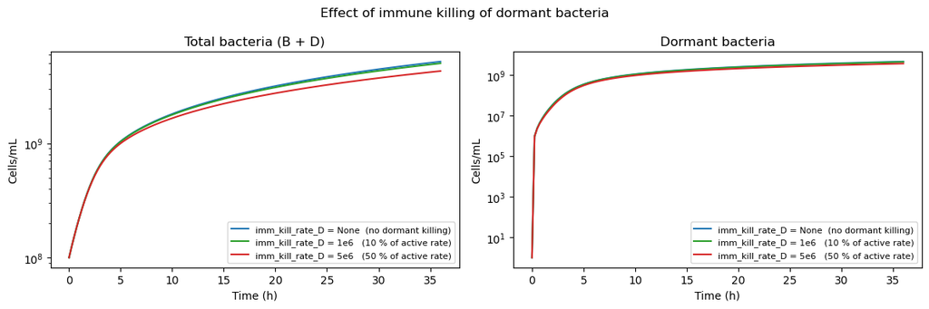

```python
BASE_DORM = (
    ModelBuilder(n_bacteria=1, n_phages=0, n_depth=3)
    .with_growth_rates(1.0, bacteria_to_resource_ratio=1e9)
    .with_growth_function(logistic_growth)
    .with_dormancy(dormancy_rate=0.3, resuscitation_rate=0.1,
                   dormancy_diffusion_rate=0.05,
                   dormancy_signal="density", resuscitation_signal="density")
    .with_nutrient(carrying_capacity=K, track_nutrients=False)
)

fig, axes = plt.subplots(1, 2, figsize=(12, 4))

# imm_kill_rate must be large enough to compete with growth at B ~ 1e8–1e9.
# Per-capita kill = imm_kill_rate * Imm / (imm_kill50 + bac_total);
# with Imm_ss ≈ 6 and bac_total ~ 1e9: rate ≈ imm_kill_rate * 6e-9.
# To achieve ~0.06 h⁻¹ kill at carrying capacity: imm_kill_rate ≈ 1e7.
for (kd, color, label) in [
    (None,  "C0", "imm_kill_rate_D = None  (no dormant killing)"),
    (1e6,   "C2", "imm_kill_rate_D = 1e6   (10 % of active rate)"),
    (5e6,   "C3", "imm_kill_rate_D = 5e6   (50 % of active rate)"),
]:
    cfg_kd = (
        BASE_DORM.with_immunity(
            immune_module   = "innate",
            imm_stim_rate   = 1.0,
            imm_kill_rate   = 1e7,
            imm_decay_rate  = 0.15,
            imm_stim50      = 5e6,
            imm_kill50      = 5e6,
            imm_kill_rate_D = kd,
        ).build()
    )
    res = solve_ode(
        PBIModel(cfg_kd, initial_B=np.array([1e8]),
                 initial_P=np.zeros(0), initial_Imm=0.0),
        t_end=T_END, dt=0.25,
    )
    B_tot = res.sum_prefixes("B", "D")
    D_tot = res.sum_prefixes("D")
    axes[0].semilogy(res.time, np.maximum(B_tot, 1), color=color, label=label)
    axes[1].semilogy(res.time, np.maximum(D_tot, 1), color=color, label=label)

for ax, title in zip(axes, ["Total bacteria (B + D)", "Dormant bacteria"]):
    ax.set(xlabel="Time (h)", ylabel="Cells/mL", title=title)
    ax.legend(fontsize=8)
plt.suptitle("Effect of immune killing of dormant bacteria")
plt.tight_layout()
plt.show()
```

## 8 Summary

| Module | `Imm` ODE | Killing formula | Use when |
| --- | --- | --- | --- |
| `'innate'` | Yes | `imm_kill_rate · Imm · B / (imm_kill50 + B_tot)` | Full immune dynamics |
| `'hill'` | No (frozen) | `imm_max · B / (imm_kill50 + B_tot)` | Simple saturation, bistability analysis |
| `'custom'` | User-defined | User-defined | Threshold, memory, non-standard models |

The **bistable clearance threshold** (Section 5) is a critical model property: `imm_max / imm_kill50 > μ` is the condition for immune clearance at low bacterial density. The threshold B* separates the basins of attraction of the two stable states (clearance and persistence).

**`imm_kill_rate_D`**: extends killing to dormant bacteria; D and H then enter `bac_total`, coupling dormant load to immune saturation.

**Next tutorial:** *Phage pharmacokinetics* — modelling phage distribution between blood and the infection site.